# Assignment 11: Detecting Overfitting and Underfitting Issues

Matthew Gray

Due: April 14, 2026

## **Assignment Objectives**

- Enhance understanding the procedure of likelihood-based chi-square hypothesis testing .
- Implement the procedures for detecting overfitting/underfitting issues in practical applications.

## **Policies of Using AI Tools**

**Policy on AI Tool Use**: Please adhere to the AI tool policy specified in the course syllabus. The direct copying of AI-generated content is strictly prohibited. All submitted work must reflect your own understanding; where external tools are consulted, content must be thoroughly rephrased and synthesized in your own words.

**Code Inclusion Requirement**: Any code included in your essay must be properly commented to explain the purpose and/or expected output of key code lines. Submitting AI-generated code without meaningful, student-added comments will not be accepted.

## Testing Overfitting/Underfitting

In Machine Learning and Statistics, overfitting occurs when a model is too complex and learns noise, leading to poor performance on new data, while underfitting happens when a model is too simple to capture important patterns, resulting in high errors overall; both issues are explained by the Bias–Variance Tradeoff and can cause unreliable predictions in real-world applications.

The probability density function (PDF) of the Weibull distribution is:

$$f(t; \lambda, \beta) = \frac{\beta}{\lambda} \left( \frac{t}{\lambda}
\right)^{\beta-1} \exp\left[ -\left( \frac{t}{\lambda} \right)^\beta
\right], \quad t \ge 0$$
where $\lambda > 0$ is the scale parameter (characteristic life) and $\beta > 0$ is the shape parameter.

When $\beta = 1$, the Weibull PDF simplifies to the exponential PDF:

$$f(t; \lambda) = \frac{1}{\lambda} \exp\left( -\frac{t}{\lambda} \right)$$
with constant hazard rate $h(t) = 1/\lambda$.

**This assignment focuses on performing a hypothesis test for the shape parameter ($\beta$) of the Weibull distribution within a reliability mode**

$$\begin{align}
H_0&: \beta = 1 \quad \text{(Exponential model, simpler)} \\
H_1&: \beta \neq 1 \quad \text{(Weibull model, more complex)}
\end{align}$$

## **Question: Reliability Application**

A mid-sized manufacturing company producing industrial conveyor systems began experiencing unexpected downtime in one of its distribution facilities, prompting concern about the reliability of a newly sourced batch of ball bearings used in the motor assemblies. These bearings, supplied by a vendor adopting cost-saving production methods, were installed across multiple units operating under continuous load conditions. After several months, maintenance logs revealed a pattern of increasing failures, with components lasting anywhere from a few dozen to over 150 hours before breakdown. To investigate, the engineering team collected time-to-failure data from 50 identical bearings and conducted a Weibull analysis within the framework of Reliability Engineering. The 50 time-to-failure (survival time) are:

```
12.4, 18.7, 25.3, 30.1, 33.5, 35.2, 38.9, 40.3, 42.7, 45.1, 47.6, 49.8, 52.4, 55.0,
57.3, 60.2, 62.8, 65.1, 67.9, 70.5, 72.3, 75.6, 78.2, 80.9, 83.4, 85.7, 88.1, 90.6,
93.2, 95.8, 98.4, 101.0, 104.5, 107.3, 110.6, 113.2, 116.8, 120.1, 123.7, 127.4,
130.9, 134.5, 138.2, 142.0, 146.3, 150.7, 155.2, 160.8, 168.4, 175.9
```

This assignment focuses on hypothesis $H_0: \beta = 1$ (exponential) against $H_1: \beta \neq 1$ (Weibull). This framework detects overfitting (fitting a Weibull when exponential is true) and underfitting (fitting exponential when Weibull with $\beta \neq 1$ is true).

a). Find the MLE of the Weibull parameters $\lambda$ (scale) and $\beta$ (shape), denoted by $\hat{\lambda}$ and $\hat{\beta}$, respectively, using the `optim()` procedure. [*Hint: You should provide explicit expressions for the log-likelihood and gradient functions of the Weibull distribution parameters.*]

Likelihood function:

$$L(\theta \mid t)
= \prod_{i=1}^{n}
\left[
\frac{\beta}{\lambda}
\left( \frac{t_i}{\lambda} \right)^{\beta - 1}
\exp\!\left(
-\left( \frac{t_i}{\lambda} \right)^{\beta}
\right)
\right]$$

Log-likelihood function:

$$\ell(\theta \mid t)
=
\sum_{i=1}^{n}
\log\!\left[
\frac{\beta}{\lambda}
\left( \frac{t_i}{\lambda} \right)^{\beta - 1}
\exp\!\left(
-\left( \frac{t_i}{\lambda} \right)^{\beta}
\right)
\right]$$

Simplification:

$$\ell(\theta \mid t)
=
\sum_{i=1}^{n}
\Bigg[
\log\!\left(\frac{\beta}{\lambda}\right)
+
\log\!\left( \left( \frac{t_i}{\lambda} \right)^{\beta - 1} \right)
+
\log\!\left(
\exp\!\left(
-\left( \frac{t_i}{\lambda} \right)^{\beta}
\right)
\right)
\Bigg]$$

$$\ell(\theta \mid t)
=
\sum_{i=1}^{n}
\Big[
\log \beta - \log \lambda
+ (\beta - 1)\big(\log t_i - \log \lambda\big)
- \left( \frac{t_i}{\lambda} \right)^{\beta}
\Big]$$

$$\ell(\theta \mid t)
=
n\log\beta
- n\log\lambda
+ (\beta - 1)\sum_{i=1}^{n}\log t_i
- (\beta - 1)n\log\lambda
- \sum_{i=1}^{n}\left( \frac{t_i}{\lambda} \right)^{\beta}$$

$$\boxed{
\ell(\theta \mid t)
=
n\log\beta
- n\beta\log\lambda
+ (\beta - 1)\sum_{i=1}^{n}\log t_i
- \sum_{i=1}^{n}\left( \frac{t_i}{\lambda} \right)^{\beta}
}$$

$$\ell(\theta \mid t)
=
n\log\beta
- n\beta\log\lambda
+ (\beta - 1)\sum_{i=1}^{n}\log t_i
- \lambda^{-\beta}\sum_{i=1}^{n} t_i^{\beta}$$

Gradient:

$$\boxed{
\frac{\partial \ell}{\partial \lambda}
=
-\frac{n\beta}{\lambda}
\;+\;
\beta\,\lambda^{-\beta-1}\sum_{i=1}^{n} t_i^{\beta}
}$$

$$\boxed{
\frac{\partial \ell}{\partial \beta}
=
\frac{n}{\beta}
- n\log\lambda
+ \sum_{i=1}^{n}\log t_i
- \sum_{i=1}^{n}\left(\frac{t_i}{\lambda}\right)^{\beta}
\log\!\left(\frac{t_i}{\lambda}\right)
}$$

```r
# --------------------------- STORING SAMPLE DATA -----------------------------------------------
fail_times <- c(12.4, 18.7, 25.3, 30.1, 33.5, 35.2, 38.9, 40.3, 42.7, 45.1, 47.6, 49.8, 52.4, 55.0,
57.3, 60.2, 62.8, 65.1, 67.9, 70.5, 72.3, 75.6, 78.2, 80.9, 83.4, 85.7, 88.1, 90.6,
93.2, 95.8, 98.4, 101.0, 104.5, 107.3, 110.6, 113.2, 116.8, 120.1, 123.7, 127.4,
130.9, 134.5, 138.2, 142.0, 146.3, 150.7, 155.2, 160.8, 168.4, 175.9)

# --------------------------- CALCULATING SAMPLE SIZE -----------------------------------------------
n <- length(fail_times)

# --------------------------- CHOOSE INITIAL VALUES FOR PARAMETERS --------------------------------------
initial_params <- c(shape = 2, scale = 2)
# These are the values you expect the parameters to take
# Shape is beta and scale is lambda
```

```r
# --------------------------- CREATING WEIBULL LOG-LIKELIHOOD FUNCTION ------------------------------------------
weibull_loglik <- function(params, data)
# weibull_loglik: function with two arguments
# params: a vector containing parameters beta (shape) and lambda (scale)
# data: sample data. In this case, the failure times of ball bearings
{
# this bracket begins the definition of the function
shape <- params[1]
# shape: beta. stored in the first position of params vector
scale <- params[2]
# scale: lambda. stored in the second position of params vector
n <- length(data)
# n: sample size
loglik <- n*log(shape) - n*shape*log(scale) + (shape - 1)*sum(log(data)) - sum((data/scale)^shape)
# loglik: Log-likelihood for Weibull distribution
return(loglik)
}
# this bracket ends the definition of the function


# --------------------------- CREATING WEIBULL GRADIENT FUNCTIONS --------------------------------------
weibull_grad <- function(params, data)
# weibull_grad: function with two arguments
{
shape <- params[1]
# shape: beta
scale <- params[2]
# scale: lambda
n <- length(data)
# n: sample size
grad_shape <- n/shape - n*log(scale) + sum(log(data)) - sum((data/scale)^(shape)*log(data/scale))
# grad_shape: gradient for beta parameter
grad_scale <- -n*shape/scale + shape*(scale^(-shape-1))*sum(data^(shape))
# grad_scale: gradient for lambda parameter
return(c(grad_shape, grad_scale))
}
# this bracket ends the definition of the function
```

Unconstrained MLEs:

```r
# --------------------------- COMPUTE PARAMETER ESTIMATES -----------------------------------------------
mle_result <- optim(
par = initial_params,
fn = weibull_loglik,
gr = weibull_grad,
data = fail_times,
method = "L-BFGS-B",
hessian = TRUE,
# Compute the second order partial derivatives and build the Hessian matrix
# The negative of this matrix is the observed Fisher information
# We can invert the Fisher information later to obtain the standard errors for beta and lambda hat
control = list(trace = FALSE,
fnscale = -1,
# this flips the direction of optimization so that optim() maximizes log-likelihood instead of minimizing
maxit = 500,
# sets the max number of iterations optim() is allowed to take before it stops
# this is a safeguard so optim() does not run forever
abstol = 1e-8)
# sets an absolute convergence tolerance so optim() stops when it is very close to a solution
)
names(mle_result$par) <- c('beta_hat', 'lambda_hat')
# rename shape to beta_hat and scale to lambda_hat

# store them as global variables
beta_hat   <- unname(mle_result$par["beta_hat"])
lambda_hat <- unname(mle_result$par["lambda_hat"])

mle_result$par # print results
```

```
  beta_hat lambda_hat
  2.206002  99.020336
```

b). Find the MLE of the exponential parameter $\lambda$ (scale), denoted by $\hat{\lambda}$, using any procedure. [*Hint: You should provide explicit expressions for the log-likelihood and gradient functions of the exponential distribution parameters.*]

Likelihood function:

$$L(\theta \mid t)
= \prod_{i=1}^{n}
\left[
\frac{1}{\lambda}
\exp\!\left(
-\frac{t_i}{\lambda}
\right)
\right]$$

Log-likelihood function:

$$\ell(\theta \mid t)
=
\sum_{i=1}^{n}
\log
\left[
\frac{1}{\lambda}
\exp\!\left(
-\frac{t_i}{\lambda}
\right)
\right]$$

Simplification:

$$\ell(\theta \mid t)
= \sum_{i=1}^{n}
\left[
\log\!\left( \frac{1}{\lambda} \right)
+ \log\!\left(
\exp\!\left(
-\frac{t_i}{\lambda}
\right)
\right)
\right]$$

$$\ell(\theta \mid t)
= -n \log(\lambda)
- \sum_{i=1}^{n} \frac{t_i}{\lambda}$$

Gradient:

$$\frac{\partial \ell}{\partial \lambda}
=
-\frac{n}{\lambda}
+
\frac{1}{\lambda^{2}}
\sum_{i=1}^{n} t_i$$

Score Equation:

$$-\frac{n}{\lambda}
+
\frac{1}{\lambda^{2}}
\sum_{i=1}^{n} t_i
= 0$$

$$\frac{1}{\lambda^{2}}
\sum_{i=1}^{n} t_i
=
\frac{n}{\lambda}$$

$$\sum_{i=1}^{n} t_i
=
n\lambda$$

$$\boxed{
\hat{\lambda}
=
\frac{1}{n}\sum_{i=1}^{n} t_i
}$$

```r
# --------------------------- STORING SAMPLE DATA -----------------------------------------------
fail_times <- c(12.4, 18.7, 25.3, 30.1, 33.5, 35.2, 38.9, 40.3, 42.7, 45.1, 47.6, 49.8, 52.4, 55.0,
57.3, 60.2, 62.8, 65.1, 67.9, 70.5, 72.3, 75.6, 78.2, 80.9, 83.4, 85.7, 88.1, 90.6,
93.2, 95.8, 98.4, 101.0, 104.5, 107.3, 110.6, 113.2, 116.8, 120.1, 123.7, 127.4,
130.9, 134.5, 138.2, 142.0, 146.3, 150.7, 155.2, 160.8, 168.4, 175.9)

# --------------------------- CALCULATING SAMPLE SIZE -----------------------------------------------
n <- length(fail_times)
```

Constrained MLEs:

```r
# constrained MLEs under H0: beta = 1
mle_constrained <- c(beta_hat_0 = 1, lambda_hat_0 = mean(fail_times))

# store as a global variable
lambda_hat_0 <- unname(mle_constrained["lambda_hat_0"])

# print results
mle_constrained
```

```
  beta_hat_0 lambda_hat_0
        1.00        87.61
```

c). Perform the likelihood ratio $\chi^2$ test on $\beta = 1$. What is the p-value? [*Hint: Use the results in a) and b)*.]

$$H_0:\ \beta = 1
\qquad\text{vs}\qquad
H_A:\ \beta \neq 1.$$

$$\Lambda
=
2\bigl[\ell(\hat{\theta}) - \ell(\tilde{\theta})\bigr]
=
2\bigl[\ell(\hat{\beta}, \hat{\lambda}) - \ell(\beta = 1,
\hat{\lambda}_0)\bigr]$$

$$\Lambda \sim \chi^{2}_{1}
\quad\text{since the full model has 2 parameters }(\beta,\lambda)\text{
and the null has 1, giving 1 degree of freedom}$$

Likelihood Ratio Statistic:

```r
LR_stat <- 2*(n*log(beta_hat) - n*beta_hat*log(lambda_hat) + (beta_hat - 1)*sum(log(fail_times)) - sum((fail_times/lambda_hat)^beta_hat) - (-n*log(lambda_hat_0) - sum(fail_times/lambda_hat_0)))

LR_stat
```

```
[1] 34.44995
```

P-value:

```r
# Compute the p-value for the likelihood ratio test
# pchisq(x, df, lower.tail = FALSE) returns P(X > x)
# This gives the right-tail probability under a chi-square(df = 1) distribution
pchisq(LR_stat, df = 1, lower.tail = FALSE)
```

```
[1] 4.373531e-09
```

**Conclusion:**

The likelihood ratio statistic was Λ = 34.45. When placed on a $\chi^2_{1}$ distribution, the corresponding p‑value is effectively zero, indicating that such a large value of Λ would be extraordinarily unlikely if the null hypothesis were true. Therefore, we reject 𝐻 0 : 𝛽 = 1 and conclude that the data provide strong evidence that the Weibull shape parameter differs from 1.

d). Perform the Wald $\chi^2$ on the same hypothesis $\beta = 1$. What is the p-value? [*Hint: You need to find the observed Fisher information matrix (i.e., the negative Hessian matrix from `optim()`) based on the Weibull distribution. The inverse of the negative observed Hessian matrix is the covariance matrix*.]

For a scalar parameter, the Wald statistic is:

$$W
\;=\;
\frac{(\hat{\beta} - \beta_0)^2}{\operatorname{Var}(\hat{\beta})}
\;=\;
\frac{(\hat{\beta} - 1)^2}{\operatorname{Var}(\hat{\beta})}$$

Wald Statistic:

```r
# Create variables for the Wald test
H <- mle_result$hessian
# H: the Hessian is extracted and stored here
fisher_info <- -H
# fisher_info: the observed fisher information is the negative expectation of the Hessian matrix
varcov <- solve(fisher_info)
# varcov: the inverse of the fisher information is the variance covariance matrix
var_beta <- varcov[1, 1]
# var_beta: extract the variance of beta_hat

# Compute the Wald Statistic
W_stat <- (beta_hat - 1)^2/var_beta
W_stat
```

```
[1] 23.11113
```

P-value:

```r
# Compute the p-value for the Wald test
# pchisq(x, df, lower.tail = FALSE) returns P(X > x)
# This gives the right-tail probability under a chi-square(df = 1) distribution
pchisq(W_stat, df = 1, lower.tail = FALSE)
```

```
[1] 1.529028e-06
```

**Conclusion:**

The Wald test statistic for testing 𝐻 0 : 𝛽 = 1 was 𝑊 = 23.11113 , which corresponds to a p‑value that is again effectively zero under a $\chi^2_{1}$ distribution. We therefore reject 𝐻 0 and conclude that the shape parameter 𝛽 differs significantly from 1.

e). Write a summary of the above analyses to address the following:

- Whether the two tests generated the same results.
- Which model is recommended for the data.
- Draw the density curve based on the MLE(s) of the parameter(s) and describe the distribution of the time-to-failure.

**Summary**

Both the Wald test and the Likelihood Ratio (LR) test were used to test 𝐻 0 : 𝛽 = 1 . Although the two test statistics differ in form, they led to the same conclusion: the null hypothesis is rejected.

In retrospect this is a highly intuitive result. Look at the graphs plotted below. The null is overly pessimistic. The new ball bearings may not last as long as they did before, but the survival time is not clustering around zero. The estimated Weibull distribution of the time to failure based on the unconstrained MLEs is bell-shaped and centered at around 75 hours. Extremely small and large survival times are not common. The distribution’s right skew is typical of manufactured parts. This just shows that some ball bearings simply last a very long time and therefore drag the distribution rightward.

Overall, I recommend the Likelihood Ratio (LR) test. Compared to the Wald test, LR is more accurate for finite samples and performs better when the likelihood is skewed. It also stays inside the parameter space, so we never create impossible estimates of parameters. This is useful for our purposes since we have a moderate sample size and assume a Weibull distribution, which is skewed and has the parameter constraint theta > 0, to build our MLEs. Wald is only better if we need to compute the MLE quickly, have limited access to computation, have a large sample, and a well-behaved likelihood.

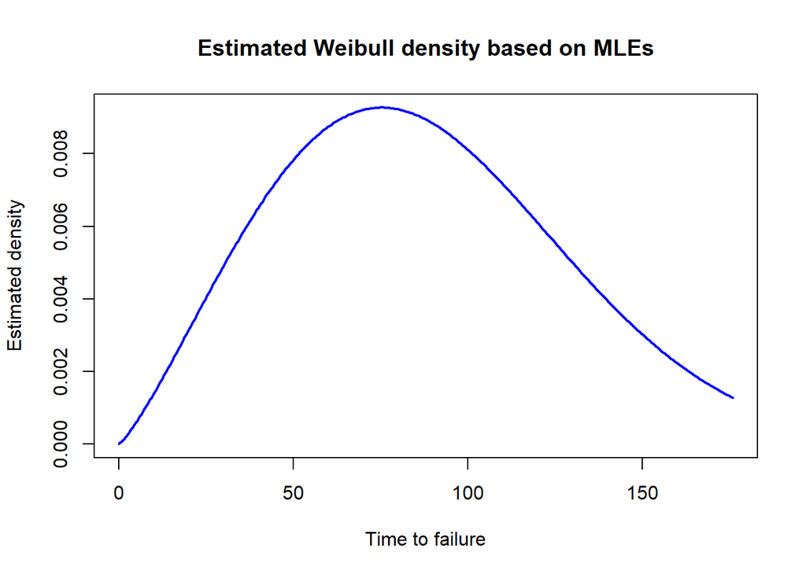

```r
t_grid <- seq(0, max(fail_times), length.out = 300)

f_hat <- dweibull(t_grid, shape = beta_hat, scale = lambda_hat)

plot(t_grid, f_hat,
     type = "l",
     lwd = 2,
     col = "blue",
     xlab = "Time to failure",
     ylab = "Estimated density",
     main = "Estimated Weibull density based on MLEs")
```

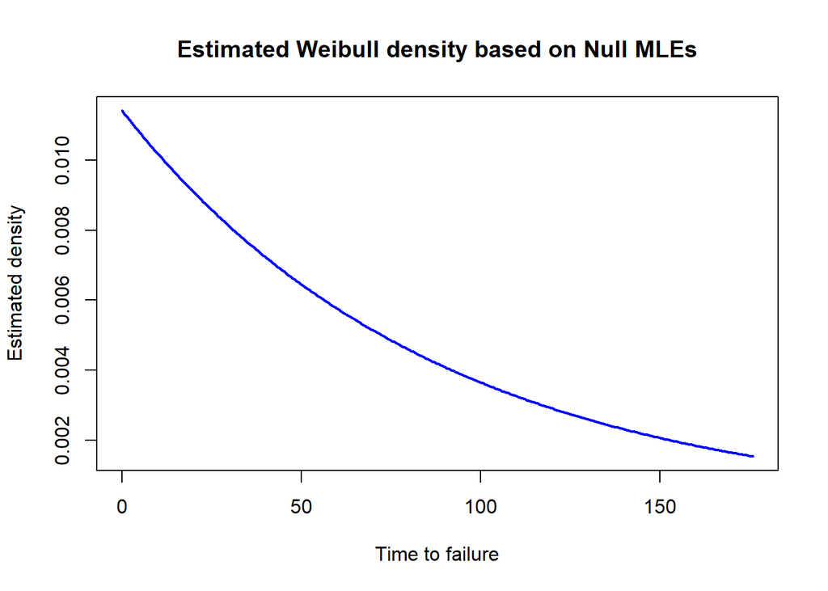

```r
beta_hat_0   <- 1   # shape

t_grid_0 <- seq(0, max(fail_times), length.out = 300)

f_hat_0 <- dweibull(t_grid_0, shape = beta_hat_0, scale = lambda_hat_0)

plot(t_grid_0, f_hat_0,
     type = "l",
     lwd = 2,
     col = "blue",
     xlab = "Time to failure",
     ylab = "Estimated density",
     main = "Estimated Weibull density based on Null MLEs")
```